# MECH481A6: Engineering Data Analysis in R

Chapter 11 Homework: Modeling

Genevieve Reyland-Slawson

14 November, 2023

# Load packages

```r
# load packages for current session
library(tidyverse)
library(gridExtra)
bodysize_csv <- "/Users/genevieve/Reyland-MECH476/data/bodysize.csv"
```

# Chapter 11 Homework

This homework will give you experience with OLS linear models and testing their assumptions.

For this first problem set, we will examine issues of *collinearity among predictor variables* when fitting an OLS model with two variables. As you recall, assumption 3 from OLS regression requires there be no *collinearity* among predictor variables (the $X_i$’s) in a linear model. The reason is that the model struggles to assign the correct $\beta_i$ values to each predictor when they are strongly correlated.

## Question 1

Fit a series of three linear models on the `bodysize.csv` data frame using `lm()` with `height` as the dependent variable:  
1. Model 1: use `waist` as the independent predictor variable:  
- `formula = height ~ waist`  
2. Model 2: use `mass` as the independent predictor variable:  
- `formula = height ~ mass`  
3. Model 3: use `mass + waist` as a linear combination of predictor variables:  
- `formula = waist + mass`

Evaluate assumption 3 about whether there is collinearity among these variables. Do you trust the coefficients from model 3 after having seen the individual coefficients reported in models 1 and 2?

## Question 2

Create a new variable in the `bodysize` data frame using `dplyr::mutate`. Call this variable `volume` and make it equal to $waist^2*height$. Use this new variable to predict `mass`.

```r
bodysize_data <- bodysize_data %>%
  dplyr::mutate(volume = waist^2 * height)
```

```r
model4 <- lm(mass ~ volume,
             data = bodysize_data)
summary(model4)
```

```
##
## Call:
## lm(formula = mass ~ volume, data = bodysize_data)
##
## Residuals:
##     Min      1Q  Median      3Q     Max
## -25.818  -5.217  -0.417   4.821  57.583
##
## Coefficients:
##              Estimate Std. Error t value Pr(>|t|)
## (Intercept) 2.546e+01  3.149e-01   80.86   <2e-16 ***
## volume      3.291e-05  1.711e-07  192.38   <2e-16 ***
## ---
## Signif. codes:  0 '***' 0.001 '**' 0.01 '*' 0.05 '.' 0.1 ' ' 1
##
## Residual standard error: 7.841 on 5173 degrees of freedom
## Multiple R-squared:  0.8774, Adjusted R-squared:  0.8773
## F-statistic: 3.701e+04 on 1 and 5173 DF,  p-value: < 2.2e-16
```

Create a scatterplot of `mass` vs. `volume` to examine the fit. Draw a fit line using `geom_smooth()`.

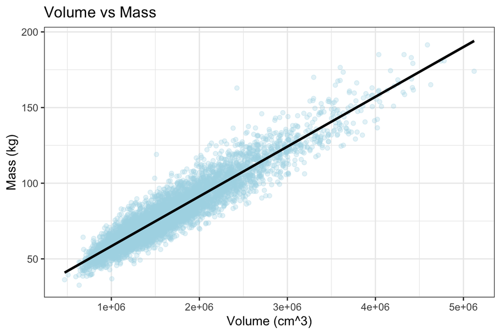

```r
q2b_plot <- ggplot(data = bodysize_data) +
  geom_point(aes(x = volume,
                 y = mass),
             alpha = 0.3,
             color = "lightblue") +
  geom_smooth(aes(x = volume,
                  y = mass),
              method = "lm",
              formula = "y ~ x",
              color = "black") +
  labs(x = "Volume (cm^3)",
       y = "Mass (kg)",
       title = "Volume vs Mass") +
  theme_bw()

q2b_plot
```

## Question 3

Load the `cal_aod.csv` data file and fit a linear model with `aeronet` as the independent variable and `AMOD` as the independent variable.

```r
# load data
caload_csv <- "/Users/genevieve/Reyland-MECH476/data/cal_aod.csv"
cal_aod <- readr::read_csv(file = caload_csv)

caload_model <- lm(formula = amod ~ aeronet,
                   data = cal_aod)
```

Evaluate model assumptions 4-7 from the coursebook. Are all these assumptions valid?

```r
#assumption 4: mean of residuals is zero
caload_mean <- mean(caload_model$residuals)
caload_mean
```

```
## [1] 2.38993e-18
```

[figure not shown]

```r
#assumption 5: residuals are normally distributed
q3b_model <- ggplot(data = caload_model$model,
                    aes(sample = caload_model$residuals)) +
  geom_qq(alpha = 0.8,
          color = "maroon") +
  geom_qq_line(color = "black") +
  scale_y_continuous(limits = c(-0.1, 0.2)) +
  labs(title = "Mass vs Waist") +
  theme_bw()
q3b_model
```

[figure not shown]

```r
#assumption 6: the error term is homoscedastic
q3c <- ggplot(data = caload_model$model) +
  geom_point(aes(x = caload_model$fitted.values,
                 y = caload_model$residuals),
             alpha = 0.8,
             color = "skyblue") +
  geom_hline(yintercept = 0) +
  labs(x = "Residuals",
       y = "Fitted Values",
       title = "Mass vs Weight") +
  theme_bw()
q3c
```

```r
#assumption 7: no autocorrelation among residuals
q3d <- cor(x = caload_model$residuals,
           y = caload_model$model[,2],
           method = "pearson")
q3d
```

```
## [1] 7.042004e-18
```